# CS 464

# Introduction to Machine Learning

# Spring 2022

# Homework 3

#### Due: DEC 23, 2022 23:59 (GMT+3)

```python
from google.colab import drive
drive.mount('/content/drive')
```

In this third homework assignment, you are asked to develop a system that can be used to supply additional information to weather forecasts. For this task, you are provided a dataset that consists of weather images that belong to four different weather conditions: [cloudy, rain, shiny, sunrise]. Your model will classify images considering these class labels.

For this assignment, **using PyTorch is mandatory.**

**Tip:** You may experience latencies in file I/O if you are using Google Colab. In this regard, we recommend you upload your data to Google Drive as a zip file and unzip the folder contents in your drive. If you would like to upload the data files separately, it may take significant time.

You will submit a single ipynb file as the homework submission. If you want to provide further explanation about your work, you can add Markdown cells to do so. [Here](https://www.markdownguide.org/), you can find a guide for Markdown syntax. Upload your homework with the following filename convention: \<BilkentID>_\<Name>_\<Surname>.ipynb

**Contact:**

- Yusuf Dalva
- Ahmet Burak Yıldırım

**Dataset**  
You can find the dataset [here](https://www.kaggle.com/datasets/pratik2901/multiclass-weather-dataset).

# **Q1** [12 points]

This part consists of 4 questions which you are expected to answer. Please fill in the following cell in Markdown format. Each question is worth 2 points.

a) Do we need to output the actual probability values when performing classification with the softmax layer? If not, how do these numbers represent the likelihood of classes? Also, does the output values should be in a specific range for us to make a classification?

b) From the perspective of model complexity, how you can identify when a model underfits or overfits? Which plots are informative for detecting this behavior?

c) In neural networks, how does the ReLU function help us to generalize to conplex feature spaces? Why we are not using linear layers only?

d) Assume that you are going to pass the feature matrix with dimensions 64x64x5 (Height x Width x Channel size) through a convolutional layer. If our convolutional layer has a kernel size of 3x3 and the number of filters is 6, how many learnable parameters are present?

## Answers of Question-1:

a) We dont need the actual probability values when performing classification at the output layer. The reason behind this situation is that, each output node represents how much likelihood the network assingns to the inputed data. Therefore, in the end the highest valued nodes label is the most probable label according to the network. Thus it predicts the data just by looking which node has the highest value. Even though the knowing which node got the highest value is sufficient for making a prediction, looking at the values in the other node can still give information about the output. For example if there is a small margin between the highest valued node and the next highest valued node, then it means that the model is not making predictions with a high confidence.

b) While building the model, the goal is to teach that model to identify the behaviour of the data and avoiding from model to memorize the exact configuration with the labels of the data. Therefore, when the model complexity is increased, the overall performance of the model can also increase to a point. After that point increasing complexity can result in a higher overfitting and lover overall performance. The reverse is also true where not making the model complex enough can result in the model not being able to produce sufficiently good enough. In this case, the model is not able to produce good results due to it lacking a good comprhension of the data which is caused by the low complexity.

c) ReLU does not activate all neurons at the same time so it works easier in complex structures. Also it converges better than other linear functions. Also, linear layers are not suitable in activation functions since linear layers behaves like data is linear.However, data can be non-linear also.

d) Formula for this question : channel_size *number of filters* filter size *+ bias 5*6*3*3 + 6 = 276

# **Q2** [88 points]

I GIVE ALL MY DISCUSSIONS IN HERE TO MAKE YOUR JOB EASIER. SINCE MY CODE IS A BIT LONG.

### DISCUSSION (FOR CNN AND FCN)

Up until now, we train FCN and CNN. When I compare both model I get the best result in CNN rather than FCN. My best accuracy is arround 0.83 in 44 batchsize 0.1 learning rate CNN version. In that case, CNN works better with bigger learning rates as I increase the learning rate I observed that the accuracy is around 0.53. Also, CNN is more succesful than the FCN about predicting Rain dataset which is the hardest one in my models. On the other hand, FCN and CNN both very succesful to predict sunrise.

IN CNN as learning rate decrease model performance goes lower and lower as I stated before. I believe that as lr goes down, model is unable to learn training data efficiently. Also, as batchsize decrease model performance is improved slightly.

Overall, CNN is better choice than FCN for this case.

### DISCUSSION FOR TRANSFER LEARNING :

Since, I give my learning rates too close. My accuricies are the same. However, I think that as learning rates increase we should get better accuricies in transfer learning. Also it should be seen in my validation accuricies in my first Transfer learning, lower learning rate, model my validation accuracy is 0.53 and in my second transfer learning model I get 0.54 validation accuracy also line converges much more better than first model.

I couldn't change batchsize in my transfer learning model since my time is very limited. Sorry.

# IMPORTANT NOTE:

IN THIS QUESTION,SINCE I DONT WANT TO USE FOR LOOP ( I COULDNT ESTIMATE THE OUTPUT).. I RUN CNN AND FCN SIX TIMES AND EACH TIME I CHANGE ONE PARAMETER. SO YOU WILL FIND SIX DIFFERENT MODELS UNDER EACH CNN AND FCN MODEL.

THE MODELS ARE INDICATED BELOW;

FCN MODELS:

- BATCHSIZE : "64" AND LR: "0.1"
- BATCHSIZE : "64" AND LR: "5e-2"
- BATCHSIZE : "64" AND LR: "5e-3"
- BATCHSIZE : "44" AND LR: "0.1"
- BATCHSIZE : "44" AND LR: "5e-2"
- BATCHSIZE : "44" AND LR: "5e-3"

CNN MODELS:

- BATCHSIZE : "64" AND LR: "0.1"
- BATCHSIZE : "64" AND LR: "5e-2"
- BATCHSIZE : "64" AND LR: "5e-3"
- BATCHSIZE : "44" AND LR: "0.1"
- BATCHSIZE : "44" AND LR: "5e-2"
- BATCHSIZE : "44" AND LR: "5e-3"

TRANSITIONAL MODELS:

- BATCHSIZE:5 AND LR :0.01
- BATCHSIZE:5 AND LR : 5e-2

So sorry about this situation. I couldnt change the structure because of the time.

## Necessary Imports

In the cell below, we import some utilities that you can make use of in this assignment. Note that you need to use PyTorch in this assignment. To report certain metrics (like precision, recall, accuracy) you may use utilities from *scikit-learn* library. You can edit these imports considering your implementation as long as you use PyTorch.

## Setup

```python
import os
import time
import random

import numpy as np
from PIL import Image
import matplotlib.pyplot as plt

import torch
import torch.nn as nn
import torch.nn.functional as F
import torchvision.models as models
from torch.utils.data import Dataset, DataLoader

from sklearn.model_selection import train_test_split
from sklearn.metrics import confusion_matrix, f1_score, precision_score, recall_score, accuracy_score
```

You can test whether hardware acceleration with GPU is enabled in the cell below. In addition, if you have GPU access, you can check the amount of available GPU memory.

```python
# setting device as GPU if available, else CPU
device = torch.device('cuda' if torch.cuda.is_available() else 'cpu')
print('Using device:', device)

# CUDA device information
if device.type == 'cuda':
    print('GPU Name:', torch.cuda.get_device_name(0))
    print('Memory Stats:')
    print('  - Allocated:', round(torch.cuda.memory_allocated(0)/1024**3,1), 'GB')
    print('  - Cached:   ', round(torch.cuda.memory_reserved(0)/1024**3,1), 'GB')
    print('  - Total:    ', round(torch.cuda.get_device_properties(0).total_memory/1024**3,1), 'GB')
```

```
Using device: cpu
```

**DO NOT CHANGE**  
To evaluate your implementation fairly, we set seed values for random sampling methods in PyTorch, Numpy, and Python random library. These seeds are set to evaluate your models successfully, so do not change these values.

```python
# for reproducable results
torch.manual_seed(464)
torch.cuda.manual_seed(464)
np.random.seed(464)
random.seed(464)
if device.type == 'cuda':
    torch.backends.cudnn.deterministic=True
```

## Load Data [6 points]

In this assignment, you will use a custom dataset, which you need a wrapper class to access its data. For this purpose, implement a custom dataset class to organize data with the specifications you need. This class will load batches of data using a PyTorch DataLoader later. The class signature of CustomDataset class is provided to you in the cell below, where you can implement your custom dataset.

**IMPORTANT:** As you may have difficulties while fitting all images to your RAM, you need to read the images while getting that item (each item is an image here). We encourage you to read the data files in the "**getitem**" function to avoid encountering any issues related to fitting the data to memory. This way, you do not need to hold the dataset in a single variable, which would be memory intensive.

```python
class CustomDataset(Dataset):

    def __init__(self, data, labels, **kwargs):
        self.data = data
        self.labels = labels

    def __len__(self):
        return len(self.data)

    def __getitem__(self, index):
        image = Image.open(self.data[index], "r")
        image = image.convert("RGB")
        image = image.resize((224,224))
        image = np.asarray(image,dtype = "float")

        def normalize(image):
            return (image - np.min(image)) / (np.max(image) - np.min(image))

        normalized_img = normalize(image)
        label = self.labels[index]
        return normalized_img, label
```

```python
def pathfinder():
    Path = "/content/drive/MyDrive/CS464_HW3/Multi-class Weather Dataset"
    FilePath = os.listdir(Path)
    if '.DS_Store' in FilePath:
        FilePath.remove('.DS_Store') #since I use Mac
    data = []
    labels = []
    for file in FilePath:
        im_path = Path + '/' + file
        for image in os.listdir(im_path):
            image_path = im_path + '/' + image
            data.append(image_path)
            if file == "Cloudy":
                labels.append(0)
            if file == "Rain":
                labels.append(1)
            if file == "Shine":
                labels.append(2)
            if file == "Sunrise":
                labels.append(3)
    return data, labels
```

```python
X,Y = pathfinder()
```

You can implement an additional function to read and construct custom dataset objects for training, validation, and test sets. While constructing the dataset, consider the following issues:

- Dataset contains images that end with prefixes *.jpg* and *.jpeg*.
- If you use PIL to read images, you should convert them to "RGB" format to operate on three color channels.
- Resize the dataset images to 224x224. You are going to design models that take images with tensor shape 224x224x3.
- If you wish, you can change the ordering of the color channels with np.moveaxis function

Lastly, the train-validation-test split for the dataset provided to you is 70-10-20 in terms of percentages. While constructing the dataset, remember that shuffling is a necessary step (to get randomly distributed classes across batches).

You can design your dataset getter method compatible with the line provided below, where train_dataset, val_dataset, and test_dataset are all instances of CustomDataset.

```python
X_train, X_test, y_train, y_test = train_test_split(X, Y, test_size=0.2, random_state=42)
X_train, X_val, y_train, y_val = train_test_split(X_train, y_train, test_size=0.125, random_state=42) # 0.125 x 0.8 = 0.1
```

```python
trains = CustomDataset(X_train, y_train)
tests = CustomDataset(X_test, y_test)
vals =  CustomDataset(X_val, y_val)

train_loader = DataLoader(trains, batch_size=64)
validation_loader = DataLoader(vals, batch_size=64)
test_loader = DataLoader(tests,batch_size=64)

print(len(train_loader))
print(len(validation_loader))
print(len(test_loader))
```

```
13
2
4
```

## Models [16 points]

In this assignment, you will implement one CNN (Convolutional Neural Network) model and one FCN (Fully-Connected Network) model, where the class signatures are provided below.

### Convolutional Neural Network (CNN) Model [8 points]

As the first model, you will implement a convolutional model. Your model will include 3 CONV + POOL blocks, which denotes one Convolutional layer followed by a Max Pooling Layer. The channel sizes for convolutional blocks are [16, 32, 64], respectively. For all convolutional layers, take kernel size as 3, stride as one, and apply padding such that convolutions do not change the shape on width and height dimensions.  
Following the convolutional part, you will perform image classification for the dataset provided to you. You can use ReLU activation as the non-linearity in your model (except the classification layer).

```python
class ConvNet(nn.Module):
    '''Define your neural network'''
    def __init__(self, **kwargs): # you can add any additional parameters you want
        super(ConvNet, self).__init__()
    # TODO:
    # You should create your neural network here
        self.conv1 = nn.Conv2d(in_channels = 3, out_channels = 16, kernel_size=3, stride=1, padding=1) #in feature 3
        self.relu = nn.ReLU()
        self.conv2 = nn.Conv2d(in_channels = 16, out_channels = 32, kernel_size=3,stride=1,padding=1)
        self.maxpool = nn.MaxPool2d(2)
        self.conv3 = nn.Conv2d(in_channels = 32, out_channels = 64, kernel_size=3,stride=1,padding=1)
        self.fc = nn.Linear(in_features = 200704, out_features = 4) #??????????????????????????????????????????????????????????
        self.output = nn.Softmax(dim=1)

    def forward(self, X): # you can add any additional parameters you want
    # TODO:
    # Forward propagation implementation should be here
        x = self.conv1(X)
        x = self.relu(x)
        x = self.conv2(x)
        x = self.relu(x)
        x = self.maxpool(x)
        x = self.conv3(x)
        x = self.relu(x)
        x = self.maxpool(x)
        x = x.reshape(x.shape[0], -1)
        x = self.fc(x)
        x = self.output(x)
        return x
```

### Fully Connected Network (FCN) Model [8 points]

The second model you will try is a Fully Connected Network composed of Linear layers and non-linear activation functions connected to each other. For this part, the number of features for your linear layers is [1024, 512, 256]. Again, you can use ReLU as your non-linear activation function in your model (except the classification layer).

```python
class FCNet(nn.Module):
    '''Define your full connected network'''
    def __init__(self, **kwargs):
        super(FCNet, self).__init__()
        self.fc1 = nn.Linear(224*224*3, 1024)
        self.fc2 = nn.Linear(1024, 512)
        self.fc3 = nn.Linear(512, 256)
        self.relu = nn.ReLU()
        self.out = nn.Linear(256, 4)

    def forward(self, x):
        x = torch.flatten(x,1) # flatten all dimensions except the batch dimension
        x = self.fc1(x)
        x = self.relu(x)
        x = self.fc2(x)
        x = self.relu(x)
        x = self.fc3(x)
        x = self.relu(x)
        x = self.out(x)
        return x
```

## Training and Evaluation of FCN [22 points]

Now that you implemented the model definition of CNN and FCN, you will train these models with the hyperparameters you chose. The hyperparameters that you may change are listed in the cell below. Using the FCN model defined, train a classifier that predicts weather condition classes specified by the dataset. For the optimizer, use [SGD](https://pytorch.org/docs/stable/generated/torch.optim.SGD.html) optimizer provided by PyTorch. You should try out different hyper-parameters like learning rates, epochs, momentum, and weight decay. For [momentum](https://machinelearningmastery.com/gradient-descent-with-momentum-from-scratch/) and [weight decay](https://paperswithcode.com/method/weight-decay), you can read about these concepts if you are interested.

While training your model, save your best model over different epochs. You must select an appropriate metric to define the best model at a time step. You can implement the training procedure in the cell below. If you want to explain the reasoning behind your metric selection, you can add a markdown cell and provide your comments.

### Training [12 points]

```python
#HINT: note that your training time should not take many days.
#TODO:
#Pick your hyper parameters

max_epoch = 14
train_batch = 64
test_batch = 64
learning_rate = 0.1
momentum = 0.5
weight_decay = 5e-04

model_FCN = FCNet()
criterion = nn.CrossEntropyLoss()
min_vald_loss = np.inf
optimizer = torch.optim.SGD(model_FCN.parameters(), lr=learning_rate, weight_decay=5e-04)

PATH_FCN_SGD = "/content/drive/MyDrive/CS464_HW3/best_fcn_sgd.pth"
min_vald_loss = np.inf
history = {'train_accuracy': [], 'vald_accuracy':[], 'train_loss': [], 'vald_loss': []}

for epoch in range(max_epoch):
    train_loss = 0.0
    train_correct = 0
    for i, data in enumerate(train_loader, 0):
        inputs, labels = data
        optimizer.zero_grad()
        input = inputs.permute(0, 3, 1, 2)
        outputs = model_FCN(input.float())
        preds = torch.argmax(outputs, dim=1)
        train_correct += torch.sum(preds==labels)
        loss = criterion(outputs, labels)
        loss.backward()
        optimizer.step()
        train_loss += loss.item()

    with torch.no_grad():
        vald_loss = 0.0
        vald_correct = 0
        for data in validation_loader:
            images, labels = data
            images = images.permute(0, 3, 1, 2)
            outputs = model_FCN(images.float())
            preds = torch.argmax(outputs, dim=1)
            vald_correct += torch.sum(preds==labels)
            loss = criterion(outputs, labels)
            vald_loss += loss.item()

    print(f'Epoch {epoch+1}:\t\t train_loss: {(train_loss / len(train_loader)):.2f}\t\t train_accuracy: {(train_correct / (len(train_loader) * train_batch)):.2f}\t\t validation_loss: {(vald_loss / len(validation_loader)):.2f}\t\t validation_accuracy: {(vald_correct / (len(validation_loader) * test_batch)):.2f}')
    if (vald_loss / len(validation_loader)) < min_vald_loss:
        print(f'Saving new best FCN SGD with vald_loss: {(vald_loss / len(validation_loader)):.2f}')
        min_vald_loss = (vald_loss / len(validation_loader))
        torch.save(model_FCN.state_dict(), PATH_FCN_SGD)

    history['train_loss'].append(train_loss / len(train_loader))
    history['vald_loss'].append(vald_loss / len(validation_loader))
    history['train_accuracy'].append(train_correct / (len(train_loader) * train_batch))
    history['vald_accuracy'].append(vald_correct / (len(validation_loader) * test_batch))

print(f'Best validation loss: {min_vald_loss}')
```

```
Epoch 1:		 train_loss: 1.39		 train_accuracy: 0.31		 validation_loss: 1.73		 validation_accuracy: 0.29
Saving new best FCN SGD with vald_loss: 1.73
Epoch 2:		 train_loss: 1.27		 train_accuracy: 0.37		 validation_loss: 1.98		 validation_accuracy: 0.33
Epoch 3:		 train_loss: 1.42		 train_accuracy: 0.45		 validation_loss: 0.95		 validation_accuracy: 0.54
Saving new best FCN SGD with vald_loss: 0.95
Epoch 4:		 train_loss: 2.02		 train_accuracy: 0.34		 validation_loss: 1.40		 validation_accuracy: 0.27
Epoch 5:		 train_loss: 1.34		 train_accuracy: 0.34		 validation_loss: 1.20		 validation_accuracy: 0.34
Epoch 6:		 train_loss: 1.40		 train_accuracy: 0.38		 validation_loss: 1.25		 validation_accuracy: 0.30
Epoch 7:		 train_loss: 1.27		 train_accuracy: 0.38		 validation_loss: 1.07		 validation_accuracy: 0.46
Epoch 8:		 train_loss: 1.31		 train_accuracy: 0.41		 validation_loss: 1.94		 validation_accuracy: 0.28
Epoch 9:		 train_loss: 1.39		 train_accuracy: 0.28		 validation_loss: 1.42		 validation_accuracy: 0.35
Epoch 10:		 train_loss: 1.24		 train_accuracy: 0.44		 validation_loss: 1.13		 validation_accuracy: 0.41
Epoch 11:		 train_loss: 1.17		 train_accuracy: 0.44		 validation_loss: 1.13		 validation_accuracy: 0.34
Epoch 12:		 train_loss: 1.19		 train_accuracy: 0.43		 validation_loss: 1.31		 validation_accuracy: 0.34
Epoch 13:		 train_loss: 1.00		 train_accuracy: 0.53		 validation_loss: 1.00		 validation_accuracy: 0.38
Epoch 14:		 train_loss: 0.96		 train_accuracy: 0.56		 validation_loss: 1.34		 validation_accuracy: 0.29
Best validation loss: 0.9486306011676788
```

### Learning Process Analysis [5 points]

Following the training step, you will now provide accuracy and loss plots over all epochs. For this, provide two plots:

- In the first plot, you will provide the value of the accuracy metric over epochs. Your plot should include two curves, one for the training set and the other for the validation set.
- For the second plot, provide the curve for loss values over epochs. Again your plot should include two curves, where one indicates loss on the training set and the second indicates loss for the validation set.

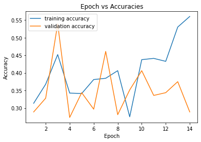

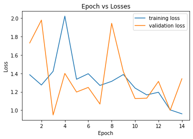

```python
"""
Plot for the listed parameters below:
max_epoch = 14
train_batch = 64
test_batch = 64
learning_rate = 0.1
momentum = 0.5
weight_decay = 5e-04
"""

# plot accuracies vs epoch -- PLOT 1
plt.plot([i+1 for i in range(max_epoch)], history['train_accuracy'], label='training accuracy')
plt.plot([i+1 for i in range(max_epoch)], history['vald_accuracy'], label='validation accuracy')
plt.xlabel('Epoch')
plt.ylabel('Accuracy')
plt.title('Epoch vs Accuracies')
plt.legend(loc='upper left')
plt.show()


# plot losses vs epoch -- PLOT 2
plt.plot([i+1 for i in range(max_epoch)], history['train_loss'], label='training loss')
plt.plot([i+1 for i in range(max_epoch)], history['vald_loss'], label='validation loss')
plt.xlabel('Epoch')
plt.ylabel('Loss')
plt.title('Epoch vs Losses')
plt.legend(loc='upper right')
plt.show()
```

### Test [5 points]

As the final step of your analysis, you will test your model using some metrics. For the best model you obtained during training, evaluate your model on the test set. Then, report the confusion matrix. Finally, report accuracy, precision, recall, and $F_1$ score using your model. Report all these metrics using the macro form (macro precision, macro recall, etc.). You can implement these metrics in the cell below.

```
Macro Precision: 0.48623824052885833 Macro Recall: 0.5480769230769231 Macro F1: 0.4670995670995671
Accuracy 0.6
Accuracies for each class:
	Accuracy for Cloudy           0.2692307692307692
	Accuracy for Rain             0.0
	Accuracy for Shine            1.0
	Accuracy for Sunrise          0.9230769230769231
```

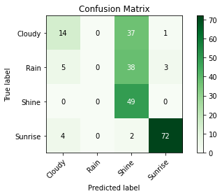

```python
"""
Plot for the listed parameters below:
max_epoch = 14
train_batch = 64
test_batch = 64
learning_rate = 0.1
momentum = 0.5
weight_decay = 5e-04
"""
def plot_cm(cm, class_labels):
    fig, ax = plt.subplots()
    im = ax.imshow(cm, interpolation='nearest', cmap=plt.cm.Greens)
    ax.figure.colorbar(im, ax=ax)
    ax.set(xticks=range(len(class_labels)),
           yticks=range(len(class_labels)),
           xticklabels=class_labels, yticklabels=class_labels,
           title="Confusion Matrix",
           ylabel='True label',
           xlabel='Predicted label')
    plt.setp(ax.get_xticklabels(), rotation=45, ha="right",
             rotation_mode="anchor")
    fmt = 'd'
    thresh = cm.max() / 2.
    for i in range(cm.shape[0]):
        for j in range(cm.shape[1]):
            ax.text(j, i, format(cm[i, j], fmt),
                    ha="center", va="center",
                    color="white" if cm[i, j] > thresh else "black")
    fig.tight_layout()
    return ax

model_fcn = FCNet()
model_fcn.load_state_dict(torch.load(PATH_FCN_SGD))

# evaluate on test set
# model = model.eval()

predictions = []

with torch.no_grad():
#   iterate over test batches
    for data in test_loader:
        images, labels = data
        images = images.permute(0, 3, 1, 2)
        #images, labels = images.cuda(), labels.cuda()
        outputs = model_fcn(images.float())
        _, predicted2 = torch.max(outputs.data, 1)
        predictions.extend(predicted2.tolist())

#   get confusion matrix
#   calculate accuracy
#   calculate precision
#   calculate recall
#   calculate F1 score
labelAndNames = {0: "Cloudy", 1: "Rain", 2: "Shine", 3: "Sunrise"}
cm = confusion_matrix(y_test,predictions)
# plot confusion matrix
plot_cm(cm, labelAndNames.values())
pscore = precision_score(y_test, predictions, average="macro")
rscore = recall_score(y_test, predictions, average="macro")
f1 = f1_score(y_test, predictions, average="macro")
print("Macro Precision:", pscore, "Macro Recall:", rscore,"Macro F1:" ,f1)
print("Accuracy", accuracy_score(y_test,predictions))
acc_per_class = cm.diagonal()/cm.sum(1)
print("Accuracies for each class:")
for i, acc in enumerate(acc_per_class):
    print(f'\tAccuracy for {labelAndNames[i]}'.ljust(30, ' '), acc)
```

```python
# The model trained according to the parameteres below (PARAMETER EXTRA TRIAL 1)

max_epoch = 14
train_batch = 64
test_batch = 64
learning_rate = 5e-2
momentum = 0.5
weight_decay = 5e-04

model_FCN = FCNet()
criterion = nn.CrossEntropyLoss()
min_vald_loss = np.inf
optimizer = torch.optim.SGD(model_FCN.parameters(), lr=learning_rate, weight_decay=5e-04)

PATH_FCN_SGD = "/content/drive/MyDrive/CS464_HW3/best_fcn_sgd.pth"
min_vald_loss = np.inf
history = {'train_accuracy': [], 'vald_accuracy':[], 'train_loss': [], 'vald_loss': []}

for epoch in range(max_epoch):
    train_loss = 0.0
    train_correct = 0
    for i, data in enumerate(train_loader, 0):
        inputs, labels = data
        optimizer.zero_grad()
        input = inputs.permute(0, 3, 1, 2)
        outputs = model_FCN(input.float())
        preds = torch.argmax(outputs, dim=1)
        train_correct += torch.sum(preds==labels)
        loss = criterion(outputs, labels)
        loss.backward()
        optimizer.step()
        train_loss += loss.item()

    with torch.no_grad():
        vald_loss = 0.0
        vald_correct = 0
        for data in validation_loader:
            images, labels = data
            images = images.permute(0, 3, 1, 2)
            outputs = model_FCN(images.float())
            preds = torch.argmax(outputs, dim=1)
            vald_correct += torch.sum(preds==labels)
            loss = criterion(outputs, labels)
            vald_loss += loss.item()

    print(f'Epoch {epoch+1}:\t\t train_loss: {(train_loss / len(train_loader)):.2f}\t\t train_accuracy: {(train_correct / (len(train_loader) * train_batch)):.2f}\t\t validation_loss: {(vald_loss / len(validation_loader)):.2f}\t\t validation_accuracy: {(vald_correct / (len(validation_loader) * test_batch)):.2f}')
    if (vald_loss / len(validation_loader)) < min_vald_loss:
        print(f'Saving new best FCN SGD with vald_loss: {(vald_loss / len(validation_loader)):.2f}')
        min_vald_loss = (vald_loss / len(validation_loader))
        torch.save(model_FCN.state_dict(), PATH_FCN_SGD)

    history['train_loss'].append(train_loss / len(train_loader))
    history['vald_loss'].append(vald_loss / len(validation_loader))
    history['train_accuracy'].append(train_correct / (len(train_loader) * train_batch))
    history['vald_accuracy'].append(vald_correct / (len(validation_loader) * test_batch))

print(f'Best validation loss: {min_vald_loss}')
```

```
Epoch 1:		 train_loss: 1.36		 train_accuracy: 0.30		 validation_loss: 1.24		 validation_accuracy: 0.47
Saving new best FCN SGD with vald_loss: 1.24
Epoch 2:		 train_loss: 1.16		 train_accuracy: 0.42		 validation_loss: 1.28		 validation_accuracy: 0.38
Epoch 3:		 train_loss: 1.18		 train_accuracy: 0.46		 validation_loss: 1.23		 validation_accuracy: 0.45
Saving new best FCN SGD with vald_loss: 1.23
Epoch 4:		 train_loss: 1.07		 train_accuracy: 0.50		 validation_loss: 0.92		 validation_accuracy: 0.53
Saving new best FCN SGD with vald_loss: 0.92
Epoch 5:		 train_loss: 0.85		 train_accuracy: 0.62		 validation_loss: 1.21		 validation_accuracy: 0.49
Epoch 6:		 train_loss: 0.88		 train_accuracy: 0.60		 validation_loss: 1.48		 validation_accuracy: 0.45
Epoch 7:		 train_loss: 1.01		 train_accuracy: 0.54		 validation_loss: 0.99		 validation_accuracy: 0.52
Epoch 8:		 train_loss: 0.87		 train_accuracy: 0.62		 validation_loss: 0.81		 validation_accuracy: 0.55
Saving new best FCN SGD with vald_loss: 0.81
Epoch 9:		 train_loss: 0.73		 train_accuracy: 0.68		 validation_loss: 0.87		 validation_accuracy: 0.56
Epoch 10:		 train_loss: 0.68		 train_accuracy: 0.68		 validation_loss: 1.12		 validation_accuracy: 0.55
Epoch 11:		 train_loss: 0.83		 train_accuracy: 0.64		 validation_loss: 0.93		 validation_accuracy: 0.57
Epoch 12:		 train_loss: 0.67		 train_accuracy: 0.70		 validation_loss: 0.87		 validation_accuracy: 0.58
Epoch 13:		 train_loss: 0.78		 train_accuracy: 0.67		 validation_loss: 0.73		 validation_accuracy: 0.61
Saving new best FCN SGD with vald_loss: 0.73
Epoch 14:		 train_loss: 0.78		 train_accuracy: 0.69		 validation_loss: 0.66		 validation_accuracy: 0.67
Saving new best FCN SGD with vald_loss: 0.66
Best validation loss: 0.6647284924983978
```

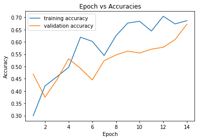

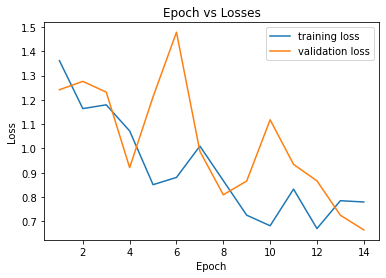

```python
# The graphs plotted according to the parameteres below (PARAMETER EXTRA TRIAL 1) batchsize =64, LR =5e-2
"""
Plot for the listed parameters below:
max_epoch = 14
train_batch = 64
test_batch = 64
learning_rate = 5e-2
momentum = 0.5
weight_decay = 5e-04
"""

# plot accuracies vs epoch -- PLOT 1
plt.plot([i+1 for i in range(max_epoch)], history['train_accuracy'], label='training accuracy')
plt.plot([i+1 for i in range(max_epoch)], history['vald_accuracy'], label='validation accuracy')
plt.xlabel('Epoch')
plt.ylabel('Accuracy')
plt.title('Epoch vs Accuracies')
plt.legend(loc='upper left')
plt.show()


# plot losses vs epoch -- PLOT 2
plt.plot([i+1 for i in range(max_epoch)], history['train_loss'], label='training loss')
plt.plot([i+1 for i in range(max_epoch)], history['vald_loss'], label='validation loss')
plt.xlabel('Epoch')
plt.ylabel('Loss')
plt.title('Epoch vs Losses')
plt.legend(loc='upper right')
plt.show()
```

```
Macro Precision: 0.7425183921386802 Macro Recall: 0.6939472277205196 Macro F1: 0.6939072394157434
Accuracy 0.7333333333333333
Accuracies for each class:
	Accuracy for Cloudy           0.6346153846153846
	Accuracy for Rain             0.391304347826087
	Accuracy for Shine            0.7755102040816326
	Accuracy for Sunrise          0.9743589743589743
```

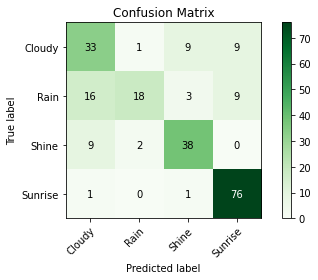

```python
# The performance metrics are calculated according to the parameteres below (PARAMETER EXTRA TRIAL 1)
"""
Plot for the listed parameters below:
max_epoch = 14
train_batch = 64
test_batch = 64
learning_rate = 5e-2
momentum = 0.5
weight_decay = 5e-04
"""
def plot_cm(cm, class_labels):
    fig, ax = plt.subplots()
    im = ax.imshow(cm, interpolation='nearest', cmap=plt.cm.Greens)
    ax.figure.colorbar(im, ax=ax)
    ax.set(xticks=range(len(class_labels)),
           yticks=range(len(class_labels)),
           xticklabels=class_labels, yticklabels=class_labels,
           title="Confusion Matrix",
           ylabel='True label',
           xlabel='Predicted label')
    plt.setp(ax.get_xticklabels(), rotation=45, ha="right",
             rotation_mode="anchor")
    fmt = 'd'
    thresh = cm.max() / 2.
    for i in range(cm.shape[0]):
        for j in range(cm.shape[1]):
            ax.text(j, i, format(cm[i, j], fmt),
                    ha="center", va="center",
                    color="white" if cm[i, j] > thresh else "black")
    fig.tight_layout()
    return ax

model_fcn = FCNet()
model_fcn.load_state_dict(torch.load(PATH_FCN_SGD))

# evaluate on test set
# model = model.eval()

predictions = []

with torch.no_grad():
#   iterate over test batches
    for data in test_loader:
        images, labels = data
        images = images.permute(0, 3, 1, 2)
        #images, labels = images.cuda(), labels.cuda()
        outputs = model_fcn(images.float())
        _, predicted2 = torch.max(outputs.data, 1)
        predictions.extend(predicted2.tolist())

#   get confusion matrix
#   calculate accuracy
#   calculate precision
#   calculate recall
#   calculate F1 score
labelAndNames = {0: "Cloudy", 1: "Rain", 2: "Shine", 3: "Sunrise"}
cm = confusion_matrix(y_test,predictions)
# plot confusion matrix
plot_cm(cm, labelAndNames.values())
pscore = precision_score(y_test, predictions, average="macro")
rscore = recall_score(y_test, predictions, average="macro")
f1 = f1_score(y_test, predictions, average="macro")
print("Macro Precision:", pscore, "Macro Recall:", rscore,"Macro F1:" ,f1)
print("Accuracy", accuracy_score(y_test,predictions))
acc_per_class = cm.diagonal()/cm.sum(1)
print("Accuracies for each class:")
for i, acc in enumerate(acc_per_class):
    print(f'\tAccuracy for {labelAndNames[i]}'.ljust(30, ' '), acc)
```

```python
# The model trained according to the parameteres below (PARAMETER EXTRA TRIAL 2)

max_epoch = 14
train_batch = 64
test_batch = 64
learning_rate = 5e-3
momentum = 0.5
weight_decay = 5e-04

model_FCN = FCNet()
criterion = nn.CrossEntropyLoss()
min_vald_loss = np.inf
optimizer = torch.optim.SGD(model_FCN.parameters(), lr=learning_rate, weight_decay=5e-04)

PATH_FCN_SGD = "/content/drive/MyDrive/CS464_HW3/best_fcn_sgd.pth"
min_vald_loss = np.inf
history = {'train_accuracy': [], 'vald_accuracy':[], 'train_loss': [], 'vald_loss': []}

for epoch in range(max_epoch):
    train_loss = 0.0
    train_correct = 0
    for i, data in enumerate(train_loader, 0):
        inputs, labels = data
        optimizer.zero_grad()
        input = inputs.permute(0, 3, 1, 2)
        outputs = model_FCN(input.float())
        preds = torch.argmax(outputs, dim=1)
        train_correct += torch.sum(preds==labels)
        loss = criterion(outputs, labels)
        loss.backward()
        optimizer.step()
        train_loss += loss.item()

    with torch.no_grad():
        vald_loss = 0.0
        vald_correct = 0
        for data in validation_loader:
            images, labels = data
            images = images.permute(0, 3, 1, 2)
            outputs = model_FCN(images.float())
            preds = torch.argmax(outputs, dim=1)
            vald_correct += torch.sum(preds==labels)
            loss = criterion(outputs, labels)
            vald_loss += loss.item()

    print(f'Epoch {epoch+1}:\t\t train_loss: {(train_loss / len(train_loader)):.2f}\t\t train_accuracy: {(train_correct / (len(train_loader) * train_batch)):.2f}\t\t validation_loss: {(vald_loss / len(validation_loader)):.2f}\t\t validation_accuracy: {(vald_correct / (len(validation_loader) * test_batch)):.2f}')
    if (vald_loss / len(validation_loader)) < min_vald_loss:
        print(f'Saving new best FCN SGD with vald_loss: {(vald_loss / len(validation_loader)):.2f}')
        min_vald_loss = (vald_loss / len(validation_loader))
        torch.save(model_FCN.state_dict(), PATH_FCN_SGD)

    history['train_loss'].append(train_loss / len(train_loader))
    history['vald_loss'].append(vald_loss / len(validation_loader))
    history['train_accuracy'].append(train_correct / (len(train_loader) * train_batch))
    history['vald_accuracy'].append(vald_correct / (len(validation_loader) * test_batch))

print(f'Best validation loss: {min_vald_loss}')
```

```
Epoch 1:		 train_loss: 1.34		 train_accuracy: 0.40		 validation_loss: 1.30		 validation_accuracy: 0.48
Saving new best FCN SGD with vald_loss: 1.30
Epoch 2:		 train_loss: 1.23		 train_accuracy: 0.57		 validation_loss: 1.19		 validation_accuracy: 0.48
Saving new best FCN SGD with vald_loss: 1.19
Epoch 3:		 train_loss: 1.12		 train_accuracy: 0.61		 validation_loss: 1.08		 validation_accuracy: 0.48
Saving new best FCN SGD with vald_loss: 1.08
Epoch 4:		 train_loss: 1.01		 train_accuracy: 0.62		 validation_loss: 0.98		 validation_accuracy: 0.49
Saving new best FCN SGD with vald_loss: 0.98
Epoch 5:		 train_loss: 0.92		 train_accuracy: 0.64		 validation_loss: 0.91		 validation_accuracy: 0.52
Saving new best FCN SGD with vald_loss: 0.91
Epoch 6:		 train_loss: 0.85		 train_accuracy: 0.66		 validation_loss: 0.85		 validation_accuracy: 0.56
Saving new best FCN SGD with vald_loss: 0.85
Epoch 7:		 train_loss: 0.79		 train_accuracy: 0.68		 validation_loss: 0.80		 validation_accuracy: 0.59
Saving new best FCN SGD with vald_loss: 0.80
Epoch 8:		 train_loss: 0.75		 train_accuracy: 0.71		 validation_loss: 0.75		 validation_accuracy: 0.60
Saving new best FCN SGD with vald_loss: 0.75
Epoch 9:		 train_loss: 0.71		 train_accuracy: 0.73		 validation_loss: 0.72		 validation_accuracy: 0.63
Saving new best FCN SGD with vald_loss: 0.72
Epoch 10:		 train_loss: 0.68		 train_accuracy: 0.73		 validation_loss: 0.69		 validation_accuracy: 0.65
Saving new best FCN SGD with vald_loss: 0.69
Epoch 11:		 train_loss: 0.65		 train_accuracy: 0.75		 validation_loss: 0.66		 validation_accuracy: 0.66
Saving new best FCN SGD with vald_loss: 0.66
Epoch 12:		 train_loss: 0.63		 train_accuracy: 0.75		 validation_loss: 0.64		 validation_accuracy: 0.68
Saving new best FCN SGD with vald_loss: 0.64
Epoch 13:		 train_loss: 0.61		 train_accuracy: 0.76		 validation_loss: 0.63		 validation_accuracy: 0.68
Saving new best FCN SGD with vald_loss: 0.63
Epoch 14:		 train_loss: 0.59		 train_accuracy: 0.77		 validation_loss: 0.61		 validation_accuracy: 0.69
Saving new best FCN SGD with vald_loss: 0.61
Best validation loss: 0.6116459667682648
```

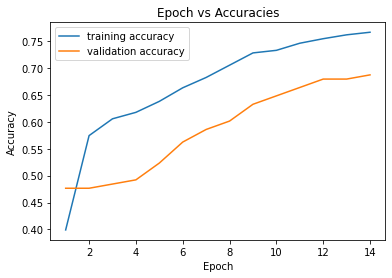

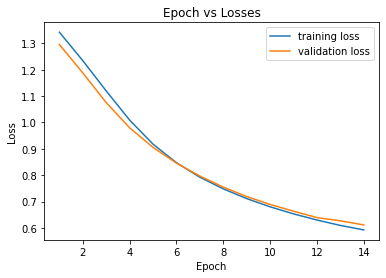

```python
# The graphs plotted according to the parameteres below (PARAMETER EXTRA TRIAL 2) batchsize =64, LR =5e-2
"""
Plot for the listed parameters below:
max_epoch = 14
train_batch = 64
test_batch = 64
learning_rate = 5e-3
momentum = 0.5
weight_decay = 5e-04
"""

# plot accuracies vs epoch -- PLOT 1
plt.plot([i+1 for i in range(max_epoch)], history['train_accuracy'], label='training accuracy')
plt.plot([i+1 for i in range(max_epoch)], history['vald_accuracy'], label='validation accuracy')
plt.xlabel('Epoch')
plt.ylabel('Accuracy')
plt.title('Epoch vs Accuracies')
plt.legend(loc='upper left')
plt.show()


# plot losses vs epoch -- PLOT 2
plt.plot([i+1 for i in range(max_epoch)], history['train_loss'], label='training loss')
plt.plot([i+1 for i in range(max_epoch)], history['vald_loss'], label='validation loss')
plt.xlabel('Epoch')
plt.ylabel('Loss')
plt.title('Epoch vs Losses')
plt.legend(loc='upper right')
plt.show()
```